# Trabajo inividual 1

Kenneth Roy Cabrera Torres

Viernes, 9 de marzo de 2018

## Primer trabajo individual

### Objetivo

Estimar un modelo de estructura espacial para el campo aleatorio del pasto, de las sombras y para las dos imágenes seleccionadas del primer taller individual.

### Procedimiento

Para cada una de las cuatro fotos realizar:

1. Estimar el modelo teórico más ajustado a “ojo”.
2. Tomar una muestra aleatoria de puntos de la imángen original usando como semilla el número de la cédula.
3. Mediante el procedimiento de detección de estructura espacial, determinar el tamaño de muestra adecuado para detectar la estructura espacial de la imagen.
4. Ajustar un modelo, ya sea gausiano, exponencial o matérn, mediante los procedimientos de mínimos cuadrados ponderados (wls) y máxima verosimilitud.
5. Determinar cuál de los dos modelos candidatos se comporta mejor utilizando la validación cruzada.
6. Realizar la predición de todo el campo aleatorio mediante kriging utilzando el mejor modelo antes seleccionado.
7. Comparara el resultados de la predicción con la imagen original obtenida.

El trabajo deberá comprender:

1. Corta introducción con respecto a las fotos que se tomaron para el ejercidio además de determinar el valor en medidas métricas para cada pixel de la imagen.
2. Una vez obtenida la predicción mediante kriging realizar observaciones, conclusiones y recomendaciones de los resultados obtenidos.
3. De acuerdo a los resultados obtenidos mediante la estimación de los modelos de las imágenes realizar conclusiones en cuanto a su propia variable planteada en el taller 1 recomendaciones como: el tamaño de muestra apropiado dada el área elegida y el modelo propuesto.

### Material entregable:

1. Imágenes utilizadas ya sea en formato png o jpg.
2. Guión con el código utilizado en formato “.Rmd”.
3. Trabajo escrito en formato “.html” sin incluir el código.

### Fecha de entrega:

Viernes 23 de marzo de 2018, antes de las 23:59 hora de Colombia al correo **krcabrer@unal.edu.co** y no olvidar en asunto la sigla **[EE]**

## Código inicial

```r
require(RandomFields)
require(rgdal)
img2 <- readGDAL("pasto1_contrastado.png")
```

```
## pasto1_contrastado.png has GDAL driver PNG
## and has 240 rows and 400 columns
```

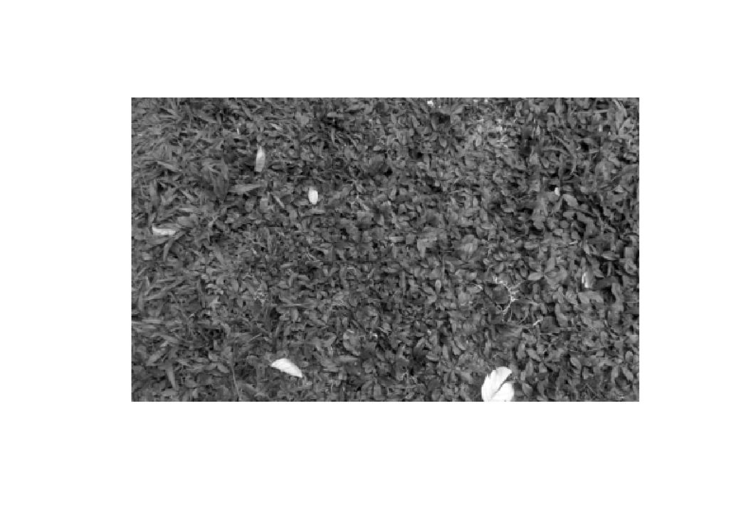

```r
image(img2, col = gray(seq(0,1, length = 256)))
```

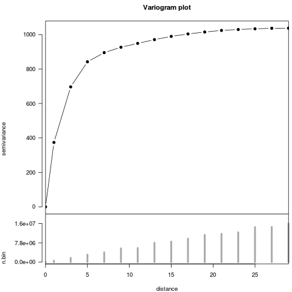

```r
# Valores de distancia está dado en pixeles.
variog2 <- RFempiricalvariogram(data = sp2RF(img2), bin = seq(0, 30, 2))
png("semivariog_pasto1.png", type = "cairo")
plot(variog2)
dev.off()
```

```r
 mean(img2$band1)
```

```
## [1] 87.61947
```

```r
 var(img2$band1)
```

```
## [1] 1083.28
```

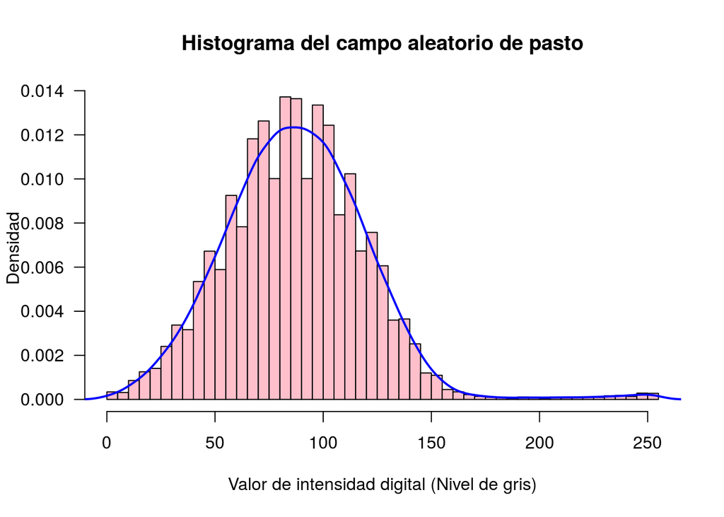

```r
hist(img2$band1, freq = FALSE, col = "pink", nclass = 50,
     main = "Histograma del campo aleatorio de pasto",
     ylab = "Densidad",
     xlab = "Valor de intensidad digital (Nivel de gris)",
     las = 1)
lines(density(img2$band1, bw = 5), col = "blue", lwd = 2)
```

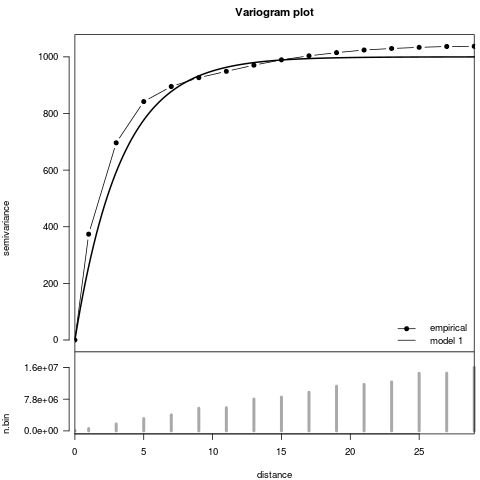

```r
# El rango práctico está dado en pixeles.
modeloExpo <- RMexp(var = 1000, scale = 10/3) + RMtrend(mean = 88)
png("semivariog_pasto12.png", type = "cairo")
plot(variog2, model=modeloExpo)
dev.off()
```

```r
# Uso de la escala de la imágen
# Esacla de la imágen 240 pixeles son 600 milímetros.
# Luego cada pixel mide 2.5 milímetros.

tamaño_pixel <- 2.5 # Milímetros
datosImg <- as.data.frame(img2)
datosImg <- datosImg[, c("x", "y", "band1")]
datosImg$x <- datosImg$x*tamaño_pixel
datosImg$y <- datosImg$y*tamaño_pixel
```

```r
# Nùmero de cédula como valor de la semilla
semilla <- 71682310
set.seed(semilla)
muestra <- datosImg[sample(1:nrow(datosImg), 100), ]
```

```r
library(geoR)
geo_muestra <- as.geodata(muestra)
summary(geo_muestra)
```

```
## Number of data points: 100
##
## Coordinates summary
##          x      y
## min   1.25   6.25
## max 983.75 596.25
##
## Distance summary
##    min    max
##    5.0 1005.5
##
## Data summary
##    Min. 1st Qu.  Median    Mean 3rd Qu.    Max.
##   11.00   56.00   85.00   83.36  105.50  154.00
```

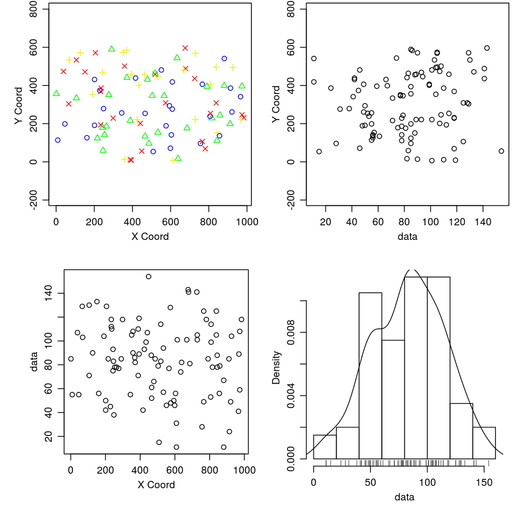

```r
plot(geo_muestra)
```